# Survey Methodology II - Final Group Project : Discrimination in the EU

### Evaluating the models

Compare AUC-ROC The AUC-ROC of Random forest model is higher than logit model

```r
logit_auc <- roc(test_data2$yes_transgender_change_documents, logit_preds)
logit_auc_value <- auc(logit_auc)
logit_auc
```

```
Call:
roc.default(response = test_data2$yes_transgender_change_documents,     predictor = logit_preds)

Data: logit_preds in 3892 controls (test_data2$yes_transgender_change_documents 0) < 4338 cases (test_data2$yes_transgender_change_documents 1).
Area under the curve: 0.8926
```

```r
logit_auc_value
```

```
Area under the curve: 0.8926
```

```r
rf_auc <- roc(test_data2$yes_transgender_change_documents, rf_preds)
rf_auc_value <- auc(rf_auc)
rf_auc
```

```
Call:
roc.default(response = test_data2$yes_transgender_change_documents,     predictor = rf_preds)

Data: rf_preds in 3892 controls (test_data2$yes_transgender_change_documents 0) < 4338 cases (test_data2$yes_transgender_change_documents 1).
Area under the curve: 0.8933
```

```r
rf_auc_value
```

```
Area under the curve: 0.8933
```

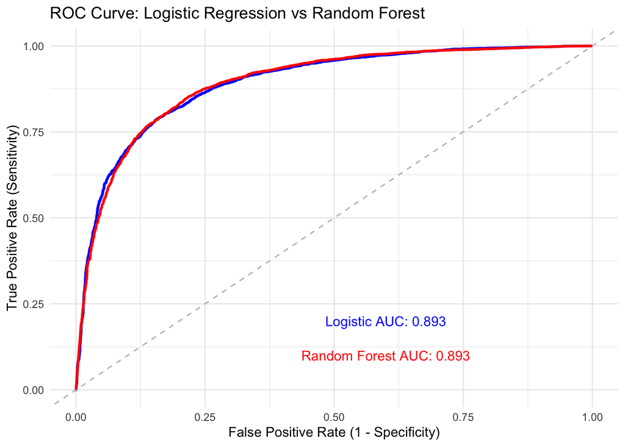

```r
ggplot() +
  geom_line(data = data.frame(FPR = 1 - logit_auc$specificities, TPR = logit_auc$sensitivities),
            aes(x = FPR, y = TPR), color = "blue", linewidth = 1) +
  geom_line(data = data.frame(FPR = 1 - rf_auc$specificities, TPR = rf_auc$sensitivities),
            aes(x = FPR, y = TPR), color = "red", linewidth = 1) +
  geom_abline(slope = 1, intercept = 0, linetype = "dashed", color = "gray") +
  labs(title = "ROC Curve: Logistic Regression vs Random Forest",
       x = "False Positive Rate (1 - Specificity)",
       y = "True Positive Rate (Sensitivity)") +
  annotate("text", x = 0.6, y = 0.2, label = paste("Logistic AUC:", round(logit_auc_value, 3)), color = "blue") +
  annotate("text", x = 0.6, y = 0.1, label = paste("Random Forest AUC:", round(rf_auc_value, 3)), color = "red") +
  theme_minimal()
```

```r
results_df <- data.frame(
  Model = c("Logistic Regression", "Random Forest"),
  AUC = c(logit_auc_value, rf_auc_value)
)
print(results_df)
```

```
                Model       AUC
1 Logistic Regression 0.8925828
2       Random Forest 0.8932914
```

Compare accuracy The Accuracy of Random forest model is higher than logit model

```r
test_data2$yes_transgender_change_documents <- as.factor(test_data2$yes_transgender_change_documents)

logit_class_preds <- factor(ifelse(logit_preds > 0.5, "1", "0"), levels = c("0", "1"))

conf_matrix_logit <- confusionMatrix(logit_class_preds, test_data2$yes_transgender_change_documents, positive = "1")

logit_accuracy <- conf_matrix_logit$overall["Accuracy"]
print(logit_accuracy)
```

```
 Accuracy
0.8121507
```

```r
rf_preds <- predict(rf_model, test_data2, type = "prob")[,2]
rf_class_preds <- factor(ifelse(rf_preds > 0.5, "1", "0"), levels = c("0", "1"))

conf_matrix_rf <- confusionMatrix(rf_class_preds, test_data2$yes_transgender_change_documents, positive = "1")

rf_accuracy <- conf_matrix_rf$overall["Accuracy"]
print(rf_accuracy)
```

```
 Accuracy
0.8154313
```

Compare F1 score The F1 socre of Random forest model is higher than logit model

```r
precision_logit <- conf_matrix_logit$byClass["Precision"]
recall_logit <- conf_matrix_logit$byClass["Recall"]
precision_rf <- conf_matrix_rf$byClass["Precision"]
recall_rf <- conf_matrix_rf$byClass["Recall"]

f1_logit <- 2 * (precision_logit * recall_logit) / (precision_logit + recall_logit)
f1_rf <- 2 * (precision_rf * recall_rf) / (precision_rf + recall_rf)

# Print the  F1-score
cat("Logistic Regression F1-score:", round(f1_logit, 3), "\n")
```

```
Logistic Regression F1-score: 0.821
```

```r
cat("Random Forest F1-score:", round(f1_rf, 3), "\n")
```

```
Random Forest F1-score: 0.825
```

In summary, the performance of random forest model is better than the other one since the rf model won in all the three evaluation ways.